# lab8art

Cassie Giovannetti

2023-06-07

```r
library(tidyverse)
library(jasmines)
library(paletteer)
library(RColorBrewer)
library(aRtsy)
library(viridis)
```

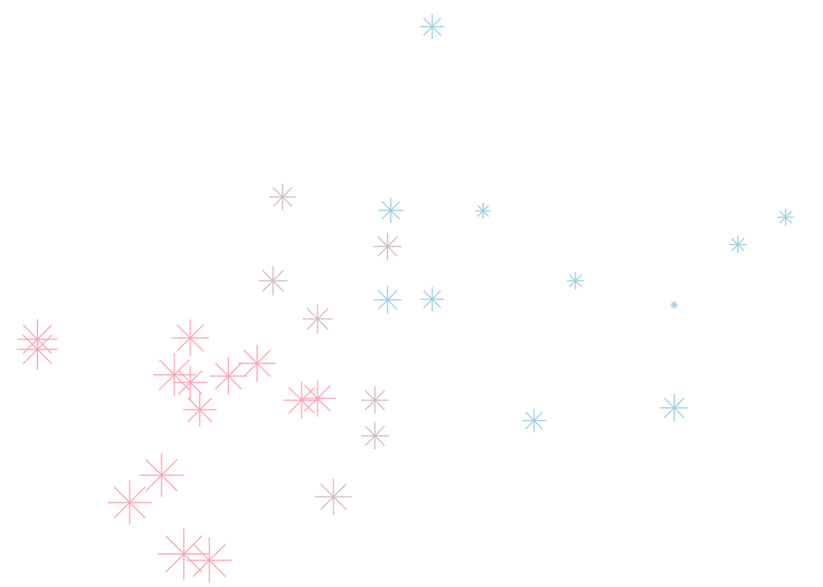

```r
mtcars$am <- factor(mtcars$am, labels = c("automatic", "manual"))
mtcars %>%
  ggplot(aes(x = mpg, y = qsec, color = cyl, size = hp)) +
  geom_point(shape = 8)+
  scale_color_gradient(high = "lightpink", low = "lightblue") +  # Apply a gradient color scale
  scale_size_continuous(range = c(1, 10)) +  # Adjust the size range
  theme_void()+
  theme(legend.position = "none")
```

### Title: Snowfall Miracle

#### The snowflakes fall first from the clouds in a lovely blue breeze before turning a shady purple as it falls. Finally, as it goes to touch the ground the snowflakes go from pruple to pink. Pink as a baby’s cheeks when they giggle.

#### I choose to do the shape snowflakes in the code with shape = 8 because it looks like snowflakes blowing in the wind. I set the color gradient from light blue to light pink as the low to have the snowflakes change color as it descends. The size was based on the horsepower of the cars in mtcars datset, which I adjusted to be from 1 to 10 in size. It looks as though the snowflakes are growing bigger as they come closer due to this.

```r
destruction <- canvas_flame(
  colors = "#39FF14",
  background = "#000000",
  iterations = 10000000,
  variations = 4,
  symmetry = 2,
  blend = TRUE,
  weighted = FALSE,
  post = FALSE,
  final = FALSE,
  extra = FALSE,
  display = "colored",
  zoom = 1,
  resolution = 1000,
  gamma = 1
)
```

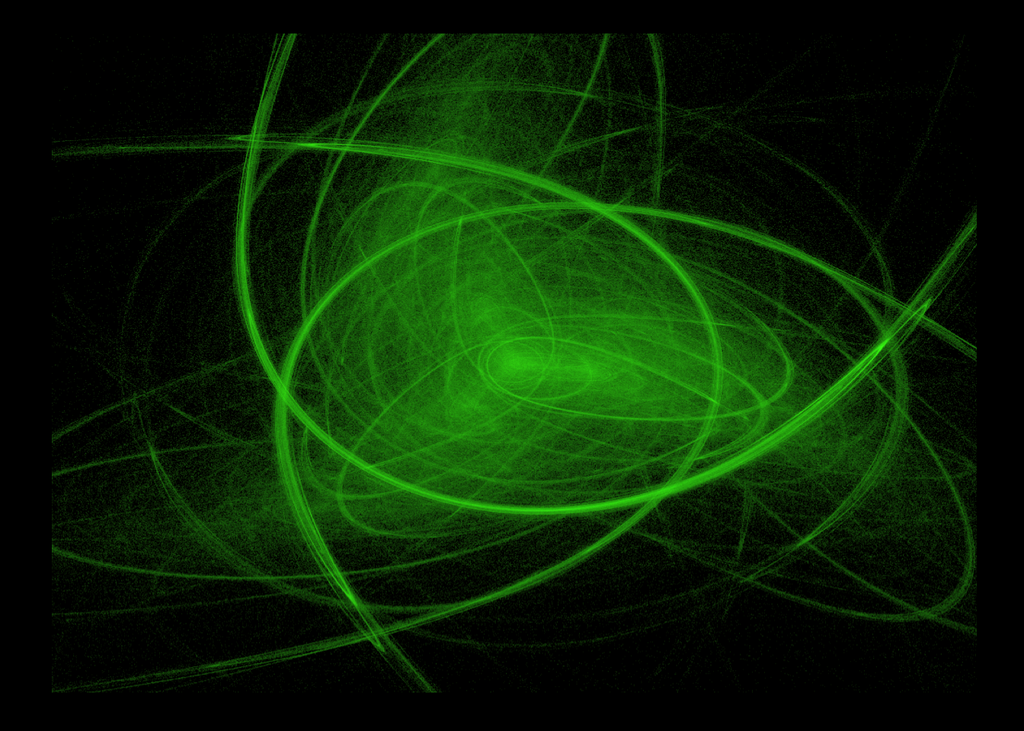

```r
destruction
```